# HT 4. Modelos de Regresion Lineal

Juan De Leon, Maria Jose Castro, Jose Block

22/03/2021

## - Modelo de Regresion Lineal

```
##    MSSubClass   LotFrontage       LotArea   OverallQual   OverallCond
##     "integer"     "integer"     "integer"     "integer"     "integer"
##     YearBuilt  YearRemodAdd    MasVnrArea    BsmtFinSF1    BsmtFinSF2
##     "integer"     "integer"     "integer"     "integer"     "integer"
##     BsmtUnfSF   TotalBsmtSF     X1stFlrSF     X2ndFlrSF  LowQualFinSF
##     "integer"     "integer"     "integer"     "integer"     "integer"
##     GrLivArea  BsmtFullBath  BsmtHalfBath      FullBath      HalfBath
##     "integer"     "integer"     "integer"     "integer"     "integer"
##  BedroomAbvGr  KitchenAbvGr  TotRmsAbvGrd    Fireplaces   GarageYrBlt
##     "integer"     "integer"     "integer"     "integer"     "integer"
##    GarageCars    GarageArea    WoodDeckSF   OpenPorchSF EnclosedPorch
##     "integer"     "integer"     "integer"     "integer"     "integer"
##    X3SsnPorch   ScreenPorch      PoolArea       MiscVal        MoSold
##     "integer"     "integer"     "integer"     "integer"     "integer"
##        YrSold    tipoDeCasa
##     "integer"     "numeric"
```

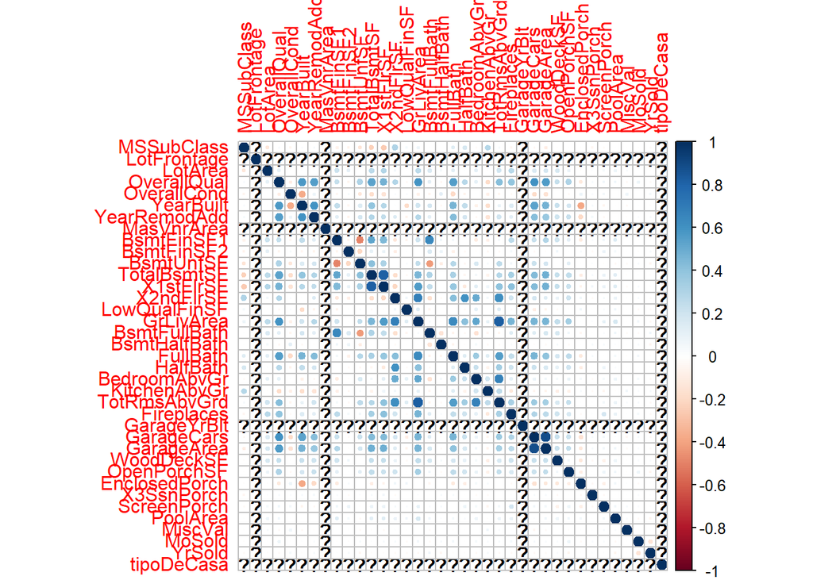

Se escoge qué variables tienen una correlación evidente, por color.Por lo tanto se decide que las variables que tienen correlación entre ellas que hay que escoger una entre esas, serían las siguientes:

TotalBsmtSF con X1stFlrSF con X2ndFlrSF, GrLivArea con TotRmsAbvGrd, BsmtFinSF1 con BsmtFullBath,y OverallQual con GarageCars con GarageArea

A continuacion se puede ver la correlacion del las variables anteriormente mencionadas con SalePrice, a partir de estos resultados escogemos que variables entre las correlacionadas se escogeran como representante del resto.

```
##                   [,1]
## OverallQual  0.7909816
## BsmtFinSF1   0.3864198
## TotalBsmtSF  0.6135806
## X1stFlrSF    0.6058522
## X2ndFlrSF    0.3193338
## GrLivArea    0.7086245
## BsmtFullBath 0.2271222
## TotRmsAbvGrd 0.5337232
## GarageCars   0.6404092
## GarageArea   0.6234314
```

A continuacion se tiene el Modelo lineal que se produjo de los datos cuantitativos:

```
##
## Call:
## lm(formula = tipoDeCasa ~ ., data = train)
##
## Coefficients:
##   (Intercept)     MSSubClass    LotFrontage        LotArea    OverallQual
##    -1.951e+01     -2.262e-03      5.592e-04      3.325e-06      1.698e-01
##   OverallCond      YearBuilt   YearRemodAdd     MasVnrArea     BsmtFinSF1
##     1.328e-02      4.442e-03      5.434e-03      5.882e-05      1.342e-04
##    BsmtFinSF2      BsmtUnfSF    TotalBsmtSF   LowQualFinSF      GrLivArea
##     2.778e-04      4.107e-05             NA      5.040e-05      2.435e-04
##  BsmtHalfBath       FullBath       HalfBath   BedroomAbvGr   KitchenAbvGr
##    -7.223e-02      2.423e-01      1.585e-01     -7.735e-03     -1.417e-01
##    Fireplaces    GarageYrBlt     WoodDeckSF    OpenPorchSF  EnclosedPorch
##     1.685e-01      3.049e-04      1.225e-04      4.546e-04      5.162e-04
##    X3SsnPorch    ScreenPorch       PoolArea        MiscVal         MoSold
##    -1.162e-04      8.706e-04     -1.156e-03      5.833e-05     -1.598e-03
##        YrSold
##    -3.500e-04
```

Luego se puede ver el tipo de data con la que vamos a trabajar y comprobar que esté en el formato correcto, con un summary().

```
## tipoDeCasa prediccion
##  "numeric"  "numeric"
```

```
##    tipoDeCasa      prediccion
##  Min.   :1.000   Min.   :1.000
##  1st Qu.:1.000   1st Qu.:1.000
##  Median :2.000   Median :2.000
##  Mean   :1.926   Mean   :1.703
##  3rd Qu.:3.000   3rd Qu.:2.000
##  Max.   :3.000   Max.   :3.000
```

Ahora la matriz de confusión que nos brinda información de la efectividad del modelo para predecir.

```
## Confusion Matrix and Statistics
##
##           prediccion
## tipoDeCasa   1   2   3
##          1 139  20   0
##          2  46  95   7
##          3  21  36  70
##
## Overall Statistics
##
##                Accuracy : 0.7005
##                  95% CI : (0.655, 0.7432)
##     No Information Rate : 0.4747
##     P-Value [Acc > NIR] : < 2.2e-16
##
##                   Kappa : 0.5431
##
##  Mcnemar's Test P-Value : 5.395e-11
##
## Statistics by Class:
##
##                      Class: 1 Class: 2 Class: 3
## Sensitivity            0.6748   0.6291   0.9091
## Specificity            0.9123   0.8127   0.8403
## Pos Pred Value         0.8742   0.6419   0.5512
## Neg Pred Value         0.7564   0.8042   0.9772
## Prevalence             0.4747   0.3479   0.1774
## Detection Rate         0.3203   0.2189   0.1613
## Detection Prevalence   0.3664   0.3410   0.2926
## Balanced Accuracy      0.7935   0.7209   0.8747
```

## - Analisis del Modelo

En este caso podemos ver que el modelo de regresion lineal es posible indicar que la efectividad del mismo fue relativamente alta. Dado que hubieron unos datos atipicos en el set de datos este el modelo no fue exato en su totalidad, pero nos pudo brindar algo muy cercano a la realidad. Se puede decir que estos datos atipicos causan alteraciones en el Modelo de Prediccion.

## - Calidad, Eficiencia, Efectividad Y del Modelo

En cuanto a la calidad del modelo debemos de comparar la calidad con las predicciones realizadas, para esto podemos ver la siguiente grafica.

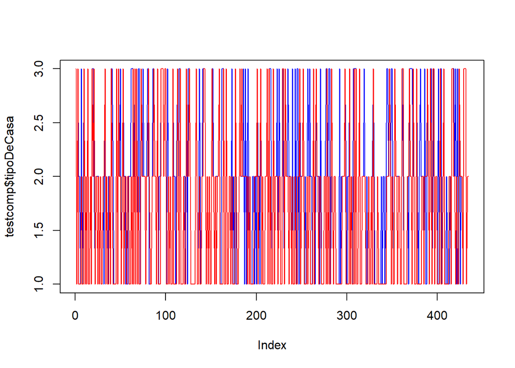

Se puede apreciar en la grafica, la linea azul muestra el set de datos de test en el que se separaron los tipos de casas (Economicas, Intermedias y Caras). De igual manera lo hizo el algoritmo de prediccion, separó e identifico cuales casas eran Economicas, Intermedias y Caras en base del conjunto de test (linea roja en la grafica), lo cual nos permite decir que fue un algoritmo eficiente ya que si realizó la tarea exitosamente. Se puso una grafica sobre la otra para poder determinar si el algoritmo clasificó con exactitud el set de datos. Como podemos ver la similitud es bastante aproximada, por lo tanto podemos concluir que la calidad del modelo fue lo suficiente para asemejarse al conjunto original, es decir, fue efectivo.

Para poder aumentar la calidad en cuanto a los datos se puede igresar una mayor cantidad de informacion o reevaluar si se pueden tomar en cuenta mas variables para aumentar la calidad y la efectividad del modelo.

## - Eficiancia del Algoritmo VS Arbol de Desicion

Por lo tanto podemos determinar que el algoritmo es eficiente. Queda abierto para poder saber si el uso de menos o mas variables podria hacer un cambio significativo en el nivel de accuracy obtenido por el algoritmo.

El cambio esperado en la accuracy al tener mas variables podria ser de disminucion por la cantidad de datos e identificacion de patrones.